# EDA of diamonds dataset

Saurabh Mathur

4 April 2016

## Introduction and setup

### Format

It has the following variables - - *price*: price in US dollars ($326–$18,823) - *carat*: weight of the diamond (0.2–5.01) - *cut*: quality of the cut (Fair, Good, Very Good, Premium, Ideal) - *color*: diamond colour, from J (worst) to D (best) - *clarity*: a measurement of how clear the diamond is (I1 (worst), SI1, SI2, VS1, VS2, VVS1, VVS2, IF (best)) - *x*: length in mm (0–10.74) - *y*: width in mm (0–58.9) - *z*: depth in mm (0–31.8) - *depth*: total depth percentage = z / mean(x, y) = 2 * z / (x + y) (43–79) - *table*: width of top of diamond relative to widest point (43–95)

### Loading the dataset

Loading the `ggplot2` library loads our dataset as well.

```r
library(ggplot2)
```

```r
sum(is.na(diamonds))
```

```
## [1] 0
```

As seen above there are no `NA` values in the dataset as it has been pre-cleaned.

## Structure

The dataset has the following columns -

```r
colnames(diamonds)
```

```
##  [1] "carat"   "cut"     "color"   "clarity" "depth"   "table"   "price"
##  [8] "x"       "y"       "z"
```

Its dimensions are given by -

```r
dim(diamonds)
```

```
## [1] 53940    10
```

The complete summary of the dataset -

```r
summary(diamonds)
```

```
##      carat               cut        color        clarity
##  Min.   :0.2000   Fair     : 1610   D: 6775   SI1    :13065
##  1st Qu.:0.4000   Good     : 4906   E: 9797   VS2    :12258
##  Median :0.7000   Very Good:12082   F: 9542   SI2    : 9194
##  Mean   :0.7979   Premium  :13791   G:11292   VS1    : 8171
##  3rd Qu.:1.0400   Ideal    :21551   H: 8304   VVS2   : 5066
##  Max.   :5.0100                     I: 5422   VVS1   : 3655
##                                     J: 2808   (Other): 2531
##      depth           table           price             x
##  Min.   :43.00   Min.   :43.00   Min.   :  326   Min.   : 0.000
##  1st Qu.:61.00   1st Qu.:56.00   1st Qu.:  950   1st Qu.: 4.710
##  Median :61.80   Median :57.00   Median : 2401   Median : 5.700
##  Mean   :61.75   Mean   :57.46   Mean   : 3933   Mean   : 5.731
##  3rd Qu.:62.50   3rd Qu.:59.00   3rd Qu.: 5324   3rd Qu.: 6.540
##  Max.   :79.00   Max.   :95.00   Max.   :18823   Max.   :10.740
##
##        y                z
##  Min.   : 0.000   Min.   : 0.000
##  1st Qu.: 4.720   1st Qu.: 2.910
##  Median : 5.710   Median : 3.530
##  Mean   : 5.735   Mean   : 3.539
##  3rd Qu.: 6.540   3rd Qu.: 4.040
##  Max.   :58.900   Max.   :31.800
##
```

## Tables

### Cut v/s Color

```r
table(diamonds$cut, diamonds$color)
```

```
##
##                D    E    F    G    H    I    J
##   Fair       163  224  312  314  303  175  119
##   Good       662  933  909  871  702  522  307
##   Very Good 1513 2400 2164 2299 1824 1204  678
##   Premium   1603 2337 2331 2924 2360 1428  808
##   Ideal     2834 3903 3826 4884 3115 2093  896
```

### Cut v/s Clarity

```r
table(diamonds$cut, diamonds$clarity)
```

```
##
##               I1  SI2  SI1  VS2  VS1 VVS2 VVS1   IF
##   Fair       210  466  408  261  170   69   17    9
##   Good        96 1081 1560  978  648  286  186   71
##   Very Good   84 2100 3240 2591 1775 1235  789  268
##   Premium    205 2949 3575 3357 1989  870  616  230
##   Ideal      146 2598 4282 5071 3589 2606 2047 1212
```

### Color v/s Clarity

```r
table(diamonds$color, diamonds$clarity)
```

```
##
##       I1  SI2  SI1  VS2  VS1 VVS2 VVS1   IF
##   D   42 1370 2083 1697  705  553  252   73
##   E  102 1713 2426 2470 1281  991  656  158
##   F  143 1609 2131 2201 1364  975  734  385
##   G  150 1548 1976 2347 2148 1443  999  681
##   H  162 1563 2275 1643 1169  608  585  299
##   I   92  912 1424 1169  962  365  355  143
##   J   50  479  750  731  542  131   74   51
```

## Plots

### Price

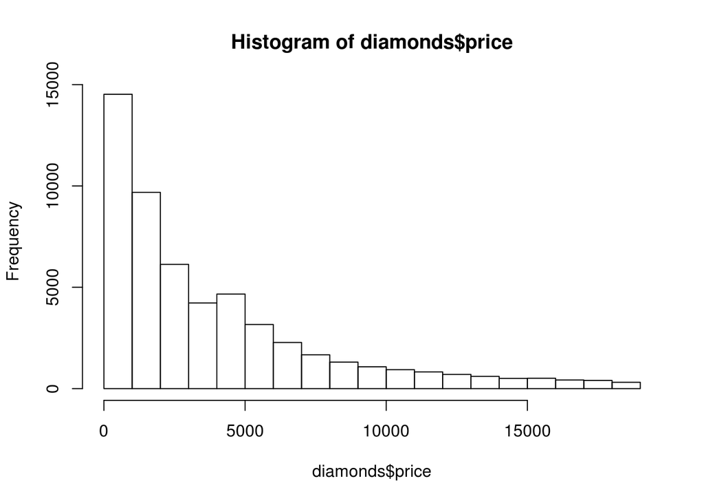

```r
hist(diamonds$price)
```

### Carat

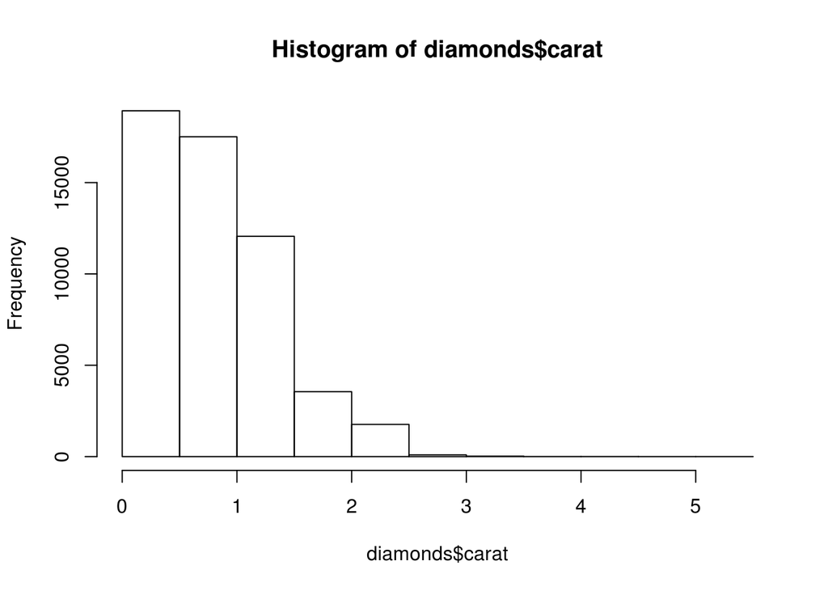

```r
hist(diamonds$carat)
```

### carat v/s Price

#### Simple

A plot of carat v/s price of diamonds using the built-in `plot` function is given as -

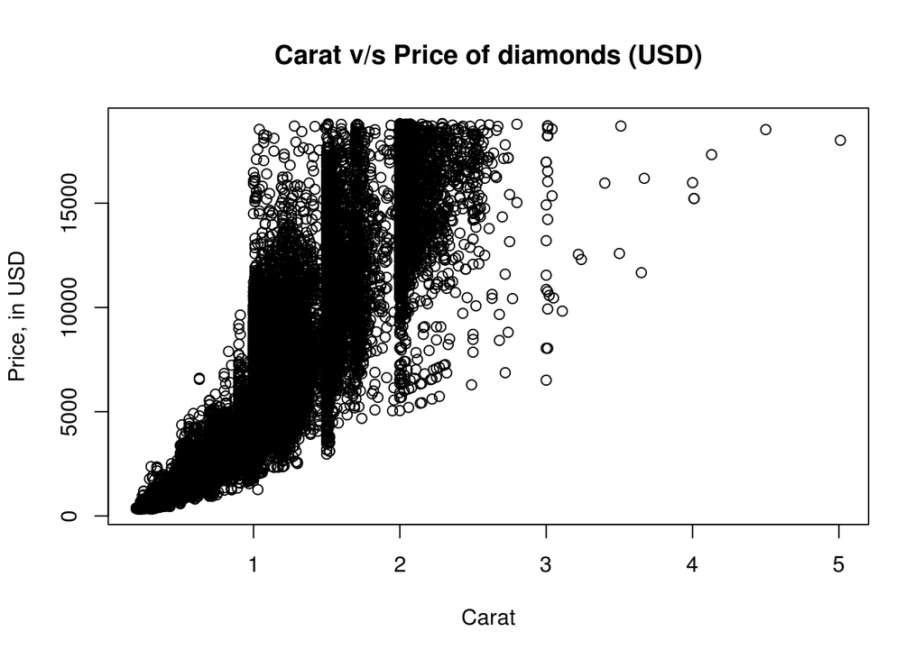

```r
plot(x = diamonds$carat, y = diamonds$price, xlab = "Carat", ylab = "Price, in USD", main = "Carat v/s Price of diamonds (USD)")
```

#### qplot

A better-looking plot of carat v/s price with cut represented by color using the function `qplot` from the `ggplot2` library loaded earlier

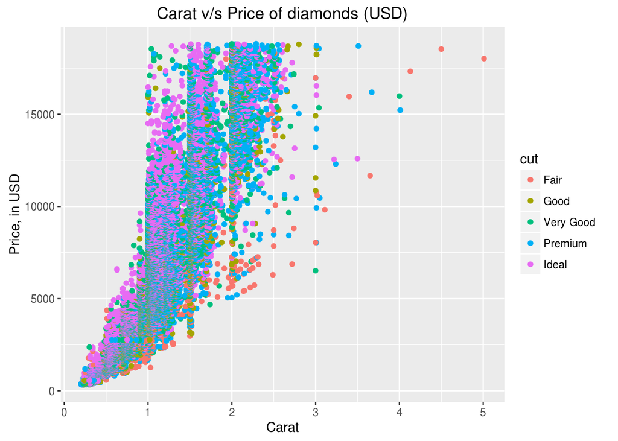

```r
qplot(data = diamonds, x = carat, y = price, xlab = "Carat", ylab = "Price, in USD", main = "Carat v/s Price of diamonds (USD)", color = cut)
```

A zoomed in version of the earlier plot (excluding some outliers)

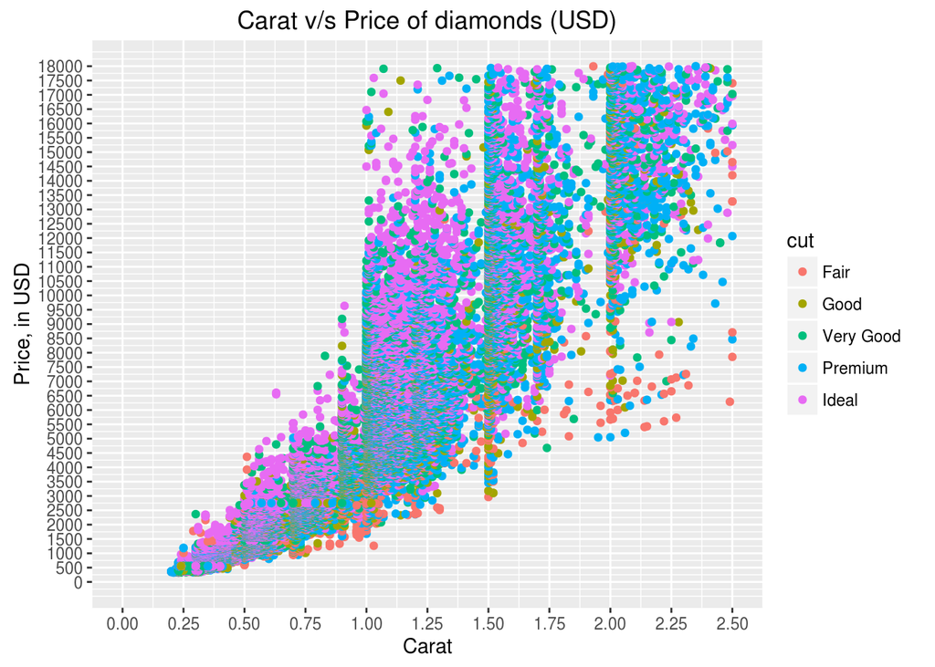

```r
qplot(data = diamonds, x = carat, y = price, xlab = "Carat", ylab = "Price, in USD", main = "Carat v/s Price of diamonds (USD)", color = cut) + scale_x_continuous(lim = c(0, 2.5), breaks = seq(0, 2.5, 0.25)) + scale_y_continuous(lim = c(0, 18000), breaks = seq(0, 18000, 500))
```

## Regression, Carat v/s Price

### Splitting the data

In order to perform cross-validation on our regression model, it is necessary to split the data into two parts namely, the `train` (80 %) and the `test` (20 %) datasets.

```r
test.indices <- sample(1:nrow(diamonds), size = 0.2 * nrow(diamonds))
test <- diamonds[test.indices, ]
train <- diamonds[-test.indices, ]

# Sanity check
nrow(test) + nrow(train) == nrow(diamonds)
```

```
## [1] TRUE
```

### Training the regression model

```r
model <- glm(data = train, formula = price ~ exp(carat))
```

### Plotting the fit

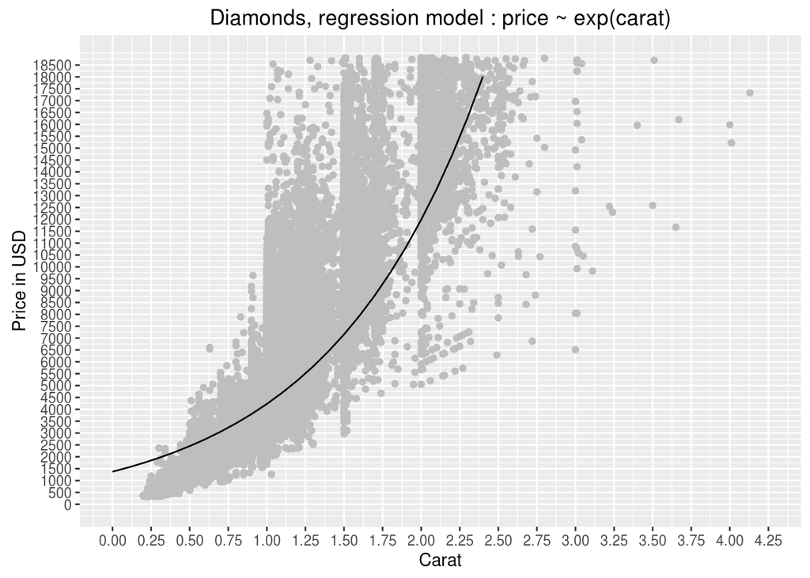

```r
xpoints <- seq(0, 5, 0.1)
ypoints <- predict(model, list(carat = xpoints))
plt <- ggplot() + geom_point(data = diamonds, aes(x = carat, y = price), color = "gray")
plt <- plt + xlab("Carat") + ylab("Price in USD") + ggtitle("Diamonds, regression model : price ~ exp(carat)")
plt <- plt + geom_line(aes(x = xpoints, y = ypoints))
plt <- plt + scale_x_continuous(lim = c(0, 4.25), breaks = seq(0, 5, 0.25))
plt <- plt + scale_y_continuous(lim = c(0, 18823), breaks = seq(0, 18823, 500))
plt
```

### Testing

The root mean square error for the model is calculated as follows -

```r
price.prediction <- predict(model, data = test)
rms.error <- sqrt(sum((price.prediction - test$price) ^ 2) / nrow(test))
rms.error
```

```
## [1] 10151.42
```